# Bilberry cover

NO_BLAA_001

Authors

Affiliations

Aud Helen Halbritter

University of Bergen

Ulrika Jansson Asplund

Norwegian Institute for Nature Research

Katrine Eldegard

Norwegian University of Life Sciences

Erik Framstad

Norwegian Institute for Nature Research

Mari Jönsson

Norwegian Institute for Nature Research

Oliver Snoksrud

Norwegian Institute of Bioeconomy Research

Ken Olaf Storaunet

Norwegian Institute of Bioeconomy Research

Published

May 7, 2026

Reviewed by

Matthew Grainger; Anders Kolstad

> **Recommended citation**: Halbritter, A. H., Jansson Asplund, U., Eldegard, K., Framstad, E., Jönsson, M., Snoksrud, O., and Storaunet, K. O. 2026. Bilberry cover (ID(s): NO_BLAA) v. 1.0.1. ecRxiv: https://github.com/NINAnor/ecRxiv/tree/main/indicators/NO_BLAA_001

**Metadata**

Table 1: Indicator metadata

[output not shown]

**Log**

- 07 May. 2026 - Original PR
- 20 May. 2026 - Change truncation and use ecTools
- 02 July. 2026 - Updated text and references
- 21 July 2026 - Accepted
- 24 August 2026 - Fix wrong indicator value in summary

## 1. Summary

1. **Background and rationale**: Bilberry (*Vaccinium myrtillus*) is a widely distributed key component of boreal forest vegetation. It provides structure to the field layer and important food resources for a wide range of invertebrates, birds and mammals. It is particularly associated with mature, moderately moist forests with intermediate crown cover, which is typical for much of intact forests under natural dynamics. Hence, the cover (%) of bilberry plants is positively associated with ecosystem condition. Data for this indicator come from the National Forest Inventory (NFI), where bilberry cover has been recorded (with current methods) for each NFI plot since 2008. The recorded mean cover of bilberries is compared to reference values for NFI regions, based on expert assessments. Higher indicator values indicate that bilberry cover is closer to the expected reference condition.
2. **Methods**: For each NFI plot, the value for the cover of bilberries is taken from the NFI variable `blaabaer_gjsn` (%). Results are calculated for sequential 5-year periods from 2010 and aggregated with area weights to county or sub-county, regional and national units. The indicator value for each county or sub-county is scaled against its specific reference level before regional and national values are calculated as area-weighted means of scaled county values.
3. **Interpretation**: An indicator value of 1 signifies that the bilberry cover is at least as extensive as expected in the reference condition. Values decreasing towards zero reflect a deteriorating condition towards complete lack of bilberry plants.
4. **Results and development needs**: For the current reporting period (2020-2024) the national indicator value is 0.77. Regions West has the highest value (0.99), and region North has the lowest value (0.55). The indicator values increase over time nationally and for all regions, except for a low decline (from a high value) in region South since the previous period. There are no specific development needs for the indicator measure. However more thorough analyses and review of the assessment of reference values and the scaling function is needed.

## 1.2 Native language summary - Norwegian

1. **Bakgrunn og begrunnelse**: Blåbær (*Vaccinium myrtillus*) er en vidt utbredt lyngplante i boreal skog. Den bidrar til struktur i feltsjiktet og er en viktig næringsplante for en rekke invertebrater, fugler og pattedyr. Blåbær er særlig knyttet til eldre, middels fuktig skog med åpninger i trekronedekket, noe som er typisk for intakt skog formet av naturlige prosesser. Dekningen (%) av blåbærplanter har dermed en positiv sammenheng med økosystemtilstanden.
2. **Metoder**: Data for denne indikatoren kommer fra Landsskogtakseringen (LSK) der blåbærplanters dekning har vært registrert (med dagens metoder) for hver LSK-prøveflate siden 2008. Data er beregnet for hvert 5-års takseringsomløp, med start i 2010 og med siste tilgjengelige data for perioden 2020-2024. Den registrerte gjennomsnittsdekningen for blåbær er sammenlignet med referanseverdier for de enkelte LSK-regionene. Referanseverdiene er basert på ekspertvurderinger støttet av data for blåbærdekning i LSK-flater i nær intakt tilstand, den regionale fordelingen av dominerende treslag, og generelle vurderinger av skogens naturlige dynamikk. Indikatoren tilsvarer samme indikator brukt i Naturindeksen for Norge, men referanseverdiene er endret etter nye vurderinger. Indikatoren er klar til bruk. Indikatoren bør ikke brukes på en finere geografisk skala enn den som gjelder for referanseverdiene (dvs. regioner).
3. **Tolkning**: Indikatorverdi 1 betyr at blåbærdekningen er minst like stor som forventet i referansetilstanden. En nedgang i verdier mot 0 innebærer en forringelse av økosystemtilstanden, mot fullstendig mangel på blåbærplanter.
4. **Resultater og utviklingsbehov**: For inneværende rapporteringsperiode (2020-2024) er indikatorverdien for hele landet 0,77. Region Vest har den høyeste verdien (0,99) og region Nord har den laveste verdien (0,55). Indikatorverdien har økt for hele landet og de fleste regionene, med unntak av en svak nedgang (fra høy verdi) i region Sør siden forrige periode. Det er ingen spesielle utviklingsbehov for selve indikatormålingen. Men mer grundige analyser, vurderinger og en revisjon av referanseverdier og skaleringsfunksjonen burde vært gjennomført.

## 2. About the underlying data

This indicator uses data from the Norwegian National Forest Inventory (NFI, Landsskogtakseringen) (Viken 2025). The bilberry cover is recorded for each NFI inventory plot. There are about 12 000 NFI plots in forest ecosystems, distributed on a regular grid, with varying grid density for forest below/above the coniferous forest line and in Finnmark county. The indicator value is an unbiased area-weighted estimate of the bilberry cover for NFI plots in any selected region. All NFI plots are sampled over a 5-year period, with a representative sampling scheme every year, allowing unbiased estimates from data for each year. For this indicator, data from each full inventory cycle of 5 years are used, starting in 2010, meaning that results reported for 2024 are based on data from the years 2020-2024. The data are available upon request from NFI.

### 2.1 Spatial and temporal resolution and extent

Data are available from 2008, when the bilberry cover was first recorded based on current methods. Annual estimates are possible due to representative sampling every year. For this indicator all data from each full inventory cycle of 5 years are used, starting in 2010. The data are representative for all forest land of Norway. Spatial resolution should be limited to the resolution applied to reference values, that is counties or sub-counties for scaling and regions for aggregated reporting.

### 2.2 Sampling design

The bilberry cover is recorded for each NFI inventory plot (Viken 2025). There are about 12 000 NFI plots in forest ecosystems, distributed on a regular grid, with varying grid density for forest below/above the coniferous forest line and in Finnmark county. In each NFI plot, bilberry cover (%) is assessed on four 0.5 m x 0.5 m subplots, placed in the cardinal directions 5 m from the centre of the NFI plot. All NFI plots are sampled over a 5-year period, with a representative sampling scheme every year, allowing unbiased estimates from data for each year.

### 2.3 Original units

The indicator is specified as the percentage (%) of the area covered by bilberry in the NFI plots. In the analyses, this value is converted to a proportion before area weighting, aggregation, and scaling.

### 2.4 Instructions for citing, using and accessing data

The data used for this indicator have been made available by the Norwegian National Forest Inventory under a specific data use agreement of 2026-05-29, between NIBIO and the specified users. Further use of these data requires a separate data user agreement with NIBIO.

## 3. Indicator properties

### 3.2 Ecosystem condition characteristic

### 3.3 Collinearities with other indicators

Bilberry cover is related to tree cover density (crown cover), with the highest values at intermediate crown cover. Correlation with other indicators related to old forest is likely.

### 3.4 Impact factors

Natural disturbances from climate variability (drought, storms) and pathogens (fungi, insects) will affect bilberry cover. Human impacts with major negative effects on bilberry cover are various forestry activities, especially open harvest types such as clear-cutting, short rotation, dense planting, and whole-tree harvesting. The most optimal light condition for bilberry plant is partial shading. Shade from the forest canopy depends on forest density, a forest attribute that can be manipulated by forest managers (Eldegard et al. 2019). Nitrogen fertilisation or pollution will reduce the health and viability of bilberry plants. Human-induced climate change with warmer/drier summers or thawing/freezing episodes in winter/early spring is also likely to have negative effects on bilberry cover.

### 3.5 Spatial aggregation

The spatial aggregation pathway is Aggregate (NFI plots to county/sub-county) – Scale – Aggregate (geographic region) – Aggregate (national level) - Truncate. For each NFI plot we first convert bilberry cover from percent to proportion and multiplied by the plot’s represented forest area. Non-scaled indicator values for each reporting period and geographic unit are then calculated as the sum of these weighted contributions divided by the sum of represented plot areas within the unit. This is done for counties or sub-counties, regions, and at national level. Scaling is applied after these non-scaled county or sub-county aggregates have been calculated: each county or sub-county is scaled against its own lower reference level *X<sub>0</sub>* (0% cover) and upper reference level *X<sub>100</sub>* using a linear scaling function without truncation. At regional level, scaled county or sub-county values are combined as area-weighted means using each unit’s represented area as weight, and values exceeding 1 on the condition scale are truncated to 0–1. At national level, these regional scaled values are aggregated in a second step as area-weighted means using regional represented areas as weights, with truncation to 0–1 applied again after this aggregation.

## 4. Reference condition and levels

The reference condition is considered to be intact forest ecosystems where effects of human activities are clearly subordinate to those of natural ecosystem processes and disturbances.

### 4.1 Reference condition

The lower reference level *X<sub>0</sub>* is set to 0% bilberry cover and the upper reference level *X<sub>100</sub>* is set separately for each county or sub-county. *X<sub>0</sub>* refers to a state with no billberry cover and *X<sub>100</sub>* to the best possible condition on the original cover scale.

### 4.2 Reference levels

The lower reference level *X<sub>0</sub>* is set to 0% bilberry cover and the upper reference level *X<sub>100</sub>* is set separately for each county or sub-county. *X<sub>0</sub>* denotes the worst possible condition and *X<sub>100</sub>* denotes the best possible condition on the original cover scale. Between *X<sub>0</sub>* and *X<sub>100</sub>*, indicator values are scaled linearly to a 0-1 indicator scale. Scaled values may exceed 1 at county or sub-county level when bilberry cover exceeds the county-specific *X<sub>100</sub>*; truncation to 1 is applied only after area-weighted aggregation to regional and national level. The county and sub-county *X<sub>100</sub>* values used in the analyses are listed in Table 3. *X<sub>0</sub>* is 0 for all units.

#### 4.2.1 Spatial resolution and validity

Reference levels are defined for regional groupings of counties or sub-counties, not as one national value. Scaling is therefore applied to area-weighted non-scaled indicator values that have first been aggregated to the matching county or sub-county unit. Regional reporting uses area-weighted aggregation of these scaled county or sub-county values, rather than applying one common *X<sub>100</sub>* to an aggregated non-scaled regional mean. National reporting applies a second area-weighted aggregation step to these regional scaled values, again without using one common *X<sub>100</sub>* for the aggregated non-scaled national mean. The indicator should not be interpreted at finer spatial resolution than the county or sub-county reference levels allow.

## 5. Uncertainties

### 5.1 General uncertainties

Reference levels are held fixed in this workflow (their own uncertainties are not propagated). Regional and national values are area-weighted summaries of counties, so they inherit both model uncertainty at county level and any mismatch between county boundaries and ecological variation within regions.

## 6. References

Eldegard, K., J. Scholten, J. N. Stokland, A. Granhus, and M. Lie. 2019. The influence of stand density on bilberry (Vaccinium myrtillus L.) cover depends on stand age, solar irradiation, and tree species composition. *Forest Ecology and Management* 432: 582–590. doi:10.1016/j.foreco.2018.09.054.

Viken, K. O. 2025. *Landsskogtakseringens feltinstruks — 2025*. Vol. 11. 8. NIBIO Bok.

## 7. Import and prepare datasets

The bilberry cover by area is recorded for each NFI plot in the LSK export. For this indicator we use data from each full 5-year inventory cycle, starting in 2010.

**Load data**

```r
lsk_data_file <- here("data/LSK_data_okologisk_tilstand_2026-06-03.csv")

lsk_data_raw <- read_csv(
  lsk_data_file,
  show_col_types = FALSE,
  locale = locale(encoding = "UTF-8")
) |>
  clean_names()
```

## 8. Spatial units

Aggregated indicator values should not be applied for spatial units finer than those that allow reliable estimates, e.g., regions.

## 9. Analyses

### 9.1 Prepare data and create derived variables

This section prepares the NFI plot data for calculating the indicator.

First we define the 5-year reporting periods that match the temporal structure of the indicator.

**Define reporting periods**

```r
# Define multiple 5-year reporting periods starting from 2010
reporting_periods <- list(
  "2010-2014" = 2010:2014,
  "2015-2019" = 2015:2019,
  "2020-2024" = 2020:2024
)
```

Next we filter the raw dataset to include both productive and unproductive forest plots (`arealtype` 1 and 12), remove records missing in the `blaabaer_gjsn` variable, and standardise the county names. NFI bilberry cover is recorded on a 0-100 percent scale and is converted to a proportion before aggregation and scaling. Area-weighted values are created `indicator_continuous_weighted = indicator_cover * au_areal` (section 9.1).

**Create derived variables**

```r
lsk_data <- lsk_data_raw |>
  filter(
    # productive and unproductive forest plots
    arealtype %in% c(1, 12)
  ) |>
  # remove records with missing data on bilberry cover
  filter(!is.na(blaabaer_gjsn)) |>
  mutate(
    fylke_name = region_fylke |>
      stringr::str_remove("^\\d+-\\d+\\s+") |>
      stringr::str_remove("^\\d+\\s*") |>
      stringr::str_squish(),
    county_part = assign_blaa_county_part(fylke_name),
    fylke_name_clean = stringi::stri_trans_general(
      stringr::str_squish(
        tolower(
          stringr::str_replace_all(
            normalize_county_parts(fylke_name),
            "[0-9.-]",
            " "
          )
        )
      ),
      "Latin-ASCII"
    ),
    region_code = assign_region_code(fylke_name_clean),
    region_name = assign_region_name(region_code),

    indicator_cover = blaabaer_gjsn / 100,
    indicator_continuous_weighted = indicator_cover * au_areal
  )
```

Finally, we retain only the columns required for subsequent aggregation and reporting.

**Select downstream fields**

```r
lsk_data <- lsk_data |>
  dplyr::select(
    sesong,
    au_areal,
    arealtype,
    region_code,
    region_name,
    county_part,
    fylke_name,
    fylke_name_clean,
    blaabaer_gjsn,
    indicator_continuous_weighted
  )
```

### 9.2 Calculate non-scaled area-weighted indicator values

For each reporting period, we calculate non-scaled indicator values separately for counties or sub-counties, regions, and the whole country. Within each geographic unit, the point estimate is the area-weighted arithmetic mean of all NFI plots in that unit: sum of `indicator_continuous_weighted` divided by sum of `au_areal`. County or sub-county estimates use the plot-level `fylke_name` field; regional estimates use `region_code`; the national estimate uses all plots in the period.

**Calculate non-scaled values**

```r
 blaa_results <- purrr::imap(
   reporting_periods,
   ~ calculate_period_indicators(lsk_data, .y, .x)
 ) |>
   purrr::compact()

 blaa_results_county_all_periods   <- purrr::map_dfr(blaa_results, "county")
 blaa_results_region_all_periods   <- purrr::map_dfr(blaa_results, "region")
 blaa_results_national_all_periods <- purrr::map_dfr(blaa_results, "national")
```

### 9.3 Bootstrap draws per county

For each county and period, NFI plots are resampled with replacement 1000 times. Each replicate computes the area-weighted mean non-scaled indicator value, giving a distribution of 1000 draws per county.

**Bootstrap draws per county (1000 per county per period)**

```r
county_draws_long <- purrr::imap_dfr(blaa_results, function(period_result, period_name) {
  county_meta <- period_result$county |>
    dplyr::select(fylke_name, county_part, total_area, region_code)

  purrr::imap_dfr(
    split(period_result$data, period_result$data$fylke_name),
    function(county_data, county_name) {
      boot <- bootstrap_indicator(county_data, n_bootstrap = 1000)
      dplyr::tibble(
        period           = period_name,
        fylke_name       = county_name,
        sim_id           = seq_along(boot$draws),
        non_scaled_value = boot$draws
      )
    }
  ) |>
    dplyr::left_join(county_meta, by = "fylke_name")
})
```

The table below (Table 2) shows the direct area-weighted mean bilberry cover per county or sub-county for all reporting periods, with approximate 95% bootstrap confidence intervals (2.5th–97.5th percentile of 1000 draws). Use the search box and page controls to browse rows.

Table 2: Non-scaled, area-weighted bilberry cover by county or sub-county for all reporting periods. Point estimate is the direct area-weighted mean from section 9.2; 95% CI is derived from 1000 bootstrap draws.

| Period | County | Sub-county | Region | Bilberry cover by area (%) | 95% CI | Total area (ha) | Number of plots |
| --- | --- | --- | --- | --- | --- | --- | --- |
| 2010-2014 | Buskerud SØ | BuS | Øst | 8.48 | 7.83 – 9.17 | 598892.2428 | 701 |
| 2010-2014 | Buskerud V | BuV | Øst | 6.68 | 5.65 – 7.86 | 164031.2488 | 157 |
| 2010-2014 | Hedmark N | HeN | Øst | 4.29 | 3.87 – 4.7 | 691306.0806 | 690 |
| 2010-2014 | Hedmark S | HeS | Øst | 7.11 | 6.62 – 7.62 | 1008745.6174 | 1211 |
| 2010-2014 | Oppland NV | OpN | Øst | 4.42 | 3.74 – 5.13 | 393212.9366 | 385 |
| 2010-2014 | Oppland SØ | OpS | Øst | 8.99 | 8.21 – 9.76 | 592595.668 | 692 |
| 2010-2014 | Oslo og Akershus | OA | Øst | 8.22 | 7.36 – 9.12 | 345444.5254 | 425 |
| 2010-2014 | Vestfold | Ve | Øst | 5.74 | 4.4 – 7.13 | 139872.1376 | 171 |
| 2010-2014 | Østfold | Øs | Øst | 5.75 | 4.98 – 6.61 | 271182.5142 | 325 |
| 2010-2014 | Aust-Agder | AA | Sør | 10.19 | 9.14 – 11.24 | 480619.5892 | 551 |

[output cut: 59 more lines]

### 9.4 Scale indicator values and aggregate to regional and national levels

County or sub-county reference levels are listed in Table 3. *X<sub>0</sub>* is 0% for all units; *X<sub>100</sub>* is the bilberry cover by area at best condition for each county or sub-county accounting unit.

**Reference values by county or sub-county**

```r
# X100 reference values (% bilberry cover by area)
blaa_reference_values <- dplyr::tibble(
  county_part = c(
    "Øs", "OA", "HeS", "HeN", "OpS", "OpN", "BuS", "BuV", "Ve",
    "TeS", "TeN", "AA", "VA", "Ro", "Ho", "SF", "MR", "ST", "NT",
    "NoS", "NoN", "Tr", "Fi"
  ),
  x100_pct = c(
    15, 16, 16, 12, 16, 11.5, 15, 11.5, 14.5,
    14, 12.5, 12, 11.5, 9.5, 10, 9.5, 10.5, 12, 13.5,
    11, 8, 7.5, 7.5
  )
) |>
  dplyr::mutate(x100 = x100_pct / 100)

x0 <- 0
county_reference <- blaa_reference_values |>
  dplyr::select(county_part, x100)
```

Table 3: County or sub-county reference values for scaling. *X<sub>0</sub>* is 0% for all units.

| Sub-county | *X*<sub>100</sub> (%) |
| --- | --- |
| Øs | 15.0 |
| OA | 16.0 |
| HeS | 16.0 |
| HeN | 12.0 |
| OpS | 16.0 |
| OpN | 11.5 |
| BuS | 15.0 |
| BuV | 11.5 |
| Ve | 14.5 |
| TeS | 14.0 |
| TeN | 12.5 |
| AA | 12.0 |
| VA | 11.5 |
| Ro | 9.5 |
| Ho | 10.0 |
| SF | 9.5 |
| MR | 10.5 |
| ST | 12.0 |
| NT | 13.5 |
| NoS | 11.0 |
| NoN | 8.0 |
| Tr | 7.5 |
| Fi | 7.5 |

Each county’s 1000 non-scaled draws from section 9.3 are linearly scaled with `ec_scale_linear()` (*X<sub>0</sub>* = 0, county-specific *X<sub>100</sub>*) without truncation. Figure 1 shows the mapping for each sub-county.

**Scale county draws (no truncation); derive county uncertainty and feed ec_upscale**

```r
county_draws_scaled <- county_draws_long |>
  dplyr::inner_join(county_reference, by = "county_part") |>
  dplyr::mutate(
    scaled_value = ec_scale_linear(
      non_scaled_value,
      x0 = x0,
      x100 = x100
    ),
    nation = "National"
  )

# Summarise scaled draws per county → county-level results table (10.1)
county_scaled_with_uncertainty <- county_draws_scaled |>
  dplyr::group_by(period, fylke_name, county_part, total_area) |>
  dplyr::summarise(
    median = median(scaled_value),
    p_025  = as.numeric(quantile(scaled_value, 0.025)),
    p_25   = as.numeric(quantile(scaled_value, 0.25)),
    p_75   = as.numeric(quantile(scaled_value, 0.75)),
    p_975  = as.numeric(quantile(scaled_value, 0.975)),
    .groups = "drop"
  ) |>
  dplyr::left_join(
    blaa_results_county_all_periods |> dplyr::select(period, fylke_name, n_plots),
    by = c("period", "fylke_name")
  )
```

**Normalisation diagnostic figure**

```r
norm_plot_data <- county_draws_scaled |>
  dplyr::group_by(county_part) |>
  dplyr::slice_sample(n = 100) |>
  dplyr::ungroup()

blaa_norm_plot <- ec_norm_plot(norm_plot_data$non_scaled_value, norm_plot_data$scaled_value) +
  ggplot2::facet_wrap(~ norm_plot_data$county_part, scales = "free_x") +
  ggplot2::labs(
    x = "Bilberry cover (proportion)",
    y = "Scaled indicator value"
  ) +
  ggplot2::theme(axis.text = ggplot2::element_text(size = 9))
blaa_norm_plot$layers[[1]]$aes_params$size <- 3

ggsave(
  filename = here::here("img/blaa_norm_plot.png"),
  plot     = blaa_norm_plot,
  scale    = 1.5
)
```

**Normalisation diagnostic figure**

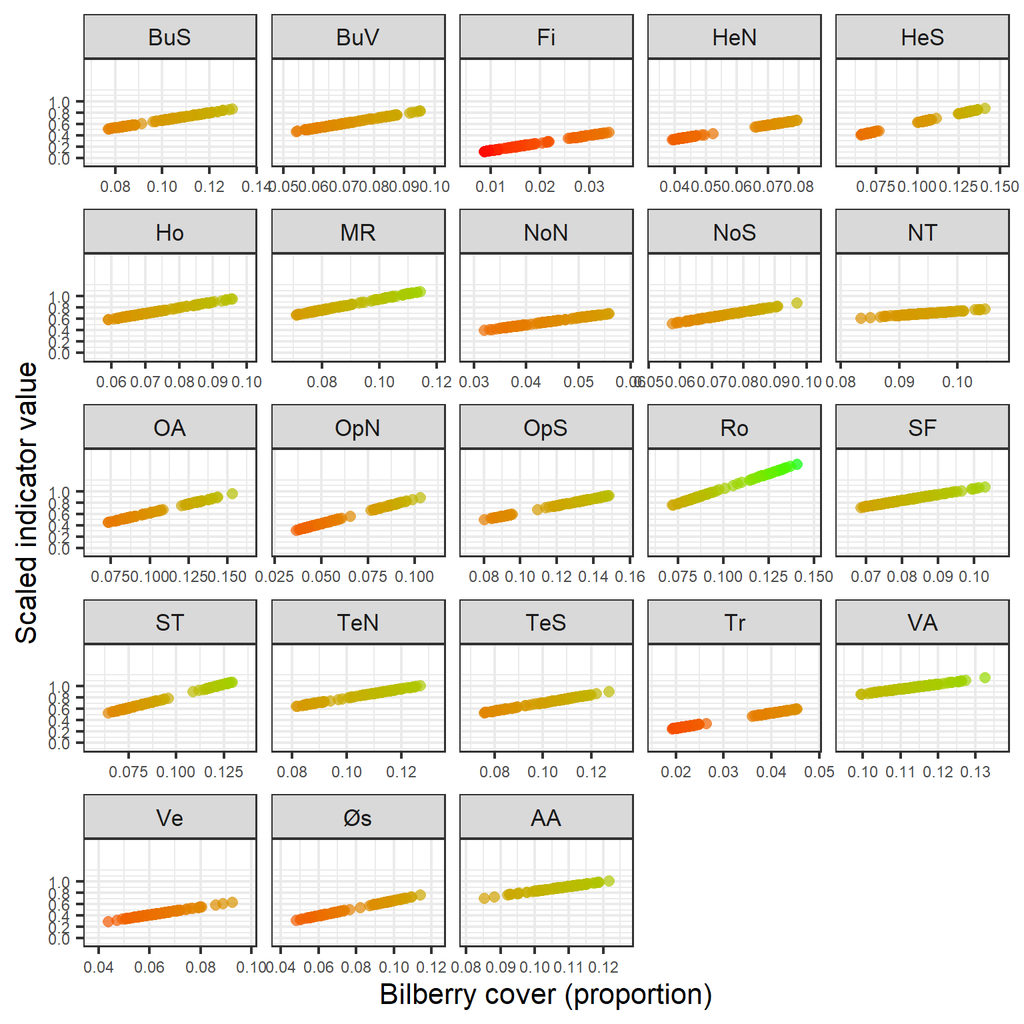

```r
blaa_norm_plot
```

The scaled draws are passed to `ecTools::ec_upscale()`, which propagates uncertainty through the spatial hierarchy. For each of 1000 Monte Carlo iterations, one draw is sampled per county and the area-weighted mean gives one regional value; a second `ec_upscale()` call repeats this from regions to national level. Truncation to the 0–1 condition scale is applied to regional and national Monte Carlo draws after aggregation.

**ec_upscale: county to region (compute once, save RDS)**

```r
blaa_mc_cache_deps <- c(
  lsk_data_file,
  here::here("R/functions.R"),
  here::here("R/NO_BLAA_001.qmd")
)
blaa_mc_rds_regional <- here::here("data/blaa_mc_regional.rds")

if (
  file.exists(blaa_mc_rds_regional) &&
  file.mtime(blaa_mc_rds_regional) >= max(file.mtime(blaa_mc_cache_deps), na.rm = TRUE)
) {
  blaa_mc_regional_raw <- readRDS(blaa_mc_rds_regional)
} else {
  blaa_mc_regional_raw <- ecTools::ec_upscale(
    data        = county_draws_scaled,
    variable    = scaled_value,
    weight      = total_area,
    start_units = fylke_name,
    end_units   = region_code,
    year        = period,
    end_units_name = "region_code",
    n = 1000
  )
  saveRDS(blaa_mc_regional_raw, blaa_mc_rds_regional)
}

blaa_mc_regional <- blaa_mc_regional_raw |>
  dplyr::mutate(
    sampled_mean_raw = sampled_mean,
    sampled_mean = ec_truncate_indicator(sampled_mean)
  )
```

**ec_upscale: region to national (compute once, save RDS)**

```r
region_area_weights <- county_draws_scaled |>
  dplyr::distinct(period, fylke_name, total_area, region_code) |>
  dplyr::group_by(period, region_code) |>
  dplyr::summarise(region_area = sum(total_area), .groups = "drop")

blaa_mc_regional_for_national <- blaa_mc_regional_raw |>
  dplyr::left_join(region_area_weights, by = c("period", "region_code")) |>
  dplyr::mutate(nation = "National")

blaa_mc_rds_national <- here::here("data/blaa_mc_national.rds")

if (
  file.exists(blaa_mc_rds_national) &&
  file.mtime(blaa_mc_rds_national) >= max(
    c(file.mtime(blaa_mc_cache_deps), file.mtime(blaa_mc_rds_regional)),
    na.rm = TRUE
  )
) {
  blaa_mc_national_raw <- readRDS(blaa_mc_rds_national)
} else {
  blaa_mc_national_raw <- ecTools::ec_upscale(
    data        = blaa_mc_regional_for_national,
    variable    = sampled_mean,
    weight      = region_area,
    start_units = region_code,
    end_units   = nation,
    year        = period,
    end_units_name = "nation",
    n = 1000
  )
  saveRDS(blaa_mc_national_raw, blaa_mc_rds_national)
}

blaa_mc_national <- blaa_mc_national_raw |>
  dplyr::mutate(
    sampled_mean_raw = sampled_mean,
    sampled_mean = ec_truncate_indicator(sampled_mean)
  )
```

**Combine regional and national MC draws; build summary tables**

```r
blaa_mc_combined <- dplyr::bind_rows(
  blaa_mc_regional |> dplyr::select(period, region = region_code, sampled_mean),
  blaa_mc_national |> dplyr::select(period, region = nation, sampled_mean)
)

county_scaled_all_periods <- blaa_results_county_all_periods |>
  dplyr::left_join(county_reference, by = "county_part") |>
  dplyr::filter(!is.na(x100)) |>
  dplyr::mutate(
    scaled_value = ec_scale_linear(indicator_value, x0 = x0, x100 = x100)
  )

region_scaled_agg_all_periods <- blaa_mc_regional |>
  dplyr::group_by(period, region_code) |>
  dplyr::summarise(
    scaled_value_raw = median(sampled_mean_raw),
    scaled_value = median(sampled_mean),
    .groups = "drop"
  ) |>
  dplyr::mutate(region_name = assign_region_name(region_code))

national_scaled_agg_all_periods <- blaa_mc_national |>
  dplyr::group_by(period) |>
  dplyr::summarise(
    scaled_value_raw = median(sampled_mean_raw),
    scaled_value = median(sampled_mean),
    .groups = "drop"
  ) |>
  dplyr::mutate(region = "National")

region_scaled_agg_with_uncertainty <- blaa_mc_regional |>
  dplyr::group_by(period, region_code) |>
  dplyr::summarise(
    median = median(sampled_mean),
    p_025  = as.numeric(quantile(sampled_mean, 0.025)),
    p_25   = as.numeric(quantile(sampled_mean, 0.25)),
    p_75   = as.numeric(quantile(sampled_mean, 0.75)),
    p_975  = as.numeric(quantile(sampled_mean, 0.975)),
    .groups = "drop"
  ) |>
  dplyr::mutate(region_name = assign_region_name(region_code)) |>
  dplyr::left_join(
    blaa_results_region_all_periods |> dplyr::select(period, region_code, total_area, n_plots),
    by = c("period", "region_code")
  )

national_scaled_agg_with_uncertainty <- blaa_mc_national |>
  dplyr::group_by(period) |>
  dplyr::summarise(
    median = median(sampled_mean),
    p_025  = as.numeric(quantile(sampled_mean, 0.025)),
    p_25   = as.numeric(quantile(sampled_mean, 0.25)),
    p_75   = as.numeric(quantile(sampled_mean, 0.75)),
    p_975  = as.numeric(quantile(sampled_mean, 0.975)),
    .groups = "drop"
  ) |>
  dplyr::mutate(region = "National") |>
  dplyr::left_join(
    blaa_results_national_all_periods |> dplyr::select(period, total_area, n_plots),
    by = "period"
  )

truncation_summary <- dplyr::bind_rows(
  region_scaled_agg_all_periods |>
    dplyr::left_join(
      blaa_results_region_all_periods |> dplyr::select(period, region_code, indicator_value),
      by = c("period", "region_code")
    ) |>
    dplyr::mutate(
      level = "Region",
      exceeds_threshold = scaled_value_raw > 1,
      original_value_pct = round(indicator_value * 100, 2),
      reference_value_pct = NA_real_,
      fylke_name = NA_character_
    ) |>
    dplyr::select(period, level, region_code, region_name, fylke_name,
                  reference_value_pct, exceeds_threshold, original_value_pct),
  national_scaled_agg_all_periods |>
    dplyr::left_join(
      blaa_results_national_all_periods |> dplyr::select(period, indicator_value),
      by = "period"
    ) |>
    dplyr::mutate(
      level = "National",
      exceeds_threshold = scaled_value_raw > 1,
      original_value_pct = round(indicator_value * 100, 2),
      reference_value_pct = NA_real_,
      region_code = NA_character_,
      region_name = "National",
      fylke_name = NA_character_
    ) |>
    dplyr::select(period, level, region_code, region_name, fylke_name,
                  reference_value_pct, exceeds_threshold, original_value_pct)
)

truncation_counts <- truncation_summary |>
  dplyr::group_by(period, level) |>
  dplyr::summarise(
    n_total = dplyr::n(),
    n_exceeding_reference = sum(exceeds_threshold, na.rm = TRUE),
    pct_exceeding_reference = round(100 * n_exceeding_reference / n_total, 1),
    .groups = "drop"
  )

truncated_values <- truncation_summary |>
  dplyr::filter(exceeds_threshold) |>
  dplyr::arrange(period, level, dplyr::desc(original_value_pct))
```

Truncation is applied only after regional and national aggregation. The tables below report cases where the area-weighted aggregated scaled value exceeded 1 before truncation (`scaled_value_raw > 1`). The following tables summarise how often this occurred in each period and list the affected units.

**Report truncation**

```r
truncation_counts |>
  dplyr::rename(
    Period = period,
    Level = level,
    `Total` = n_total,
    `Exceeding reference` = n_exceeding_reference,
    `% Exceeding reference` = pct_exceeding_reference
  ) |>
  gt::gt() |>
  gt::tab_style(
    style = gt::cell_text(weight = "bold"),
    locations = gt::cells_column_labels()
  ) |>
  gt::fmt_number(
    columns = `% Exceeding reference`,
    decimals = 1
  )
```

| Period | Level | Total | Exceeding reference | % Exceeding reference |
| --- | --- | --- | --- | --- |
| 2010-2014 | National | 1 | 0 | 0.0 |
| 2010-2014 | Region | 5 | 0 | 0.0 |
| 2015-2019 | National | 1 | 0 | 0.0 |
| 2015-2019 | Region | 5 | 0 | 0.0 |
| 2020-2024 | National | 1 | 0 | 0.0 |
| 2020-2024 | Region | 5 | 0 | 0.0 |

**Report truncation**

```r
if (nrow(truncated_values) > 0) {
  truncated_values |>
    dplyr::mutate(
      location = dplyr::case_when(
        level == "County" ~ fylke_name,
        level == "Region" ~ region_name,
        level == "National" ~ "National",
        TRUE ~ NA_character_
      )
    ) |>
    dplyr::select(
      period,
      level,
      location,
      reference_value_pct,
      original_value_pct
    ) |>
    dplyr::rename(
      Period = period,
      Level = level,
      Location = location,
      `Reference (%)` = reference_value_pct,
      `Original Value (%)` = original_value_pct
    ) |>
    gt::gt() |>
    gt::tab_style(
      style = gt::cell_text(weight = "bold"),
      locations = gt::cells_column_labels()
    ) |>
    gt::fmt_number(
      columns = c(`Reference (%)`, `Original Value (%)`),
      decimals = 1
    )
} else {
  cat("\nNo values exceeded their reference and required truncation.\n")
}
```

```
No values exceeded their reference and required truncation.
```

## 10. Results

The following tables present scaled indicator results at county or sub-county, regional, and national scales for each reporting period. County values are linearly scaled without truncation; regional and national values are truncated to 0–1 after area-weighted aggregation (section 9.4). Tables report the median as the indicator value, with an approximate 95% interval (2.5% and 97.5% quantiles) and an approximate interquartile range (25% and 75% quantiles).

The time series below (Figure 2) summarises regional and national values.

**Time series of indicator values by region and period**

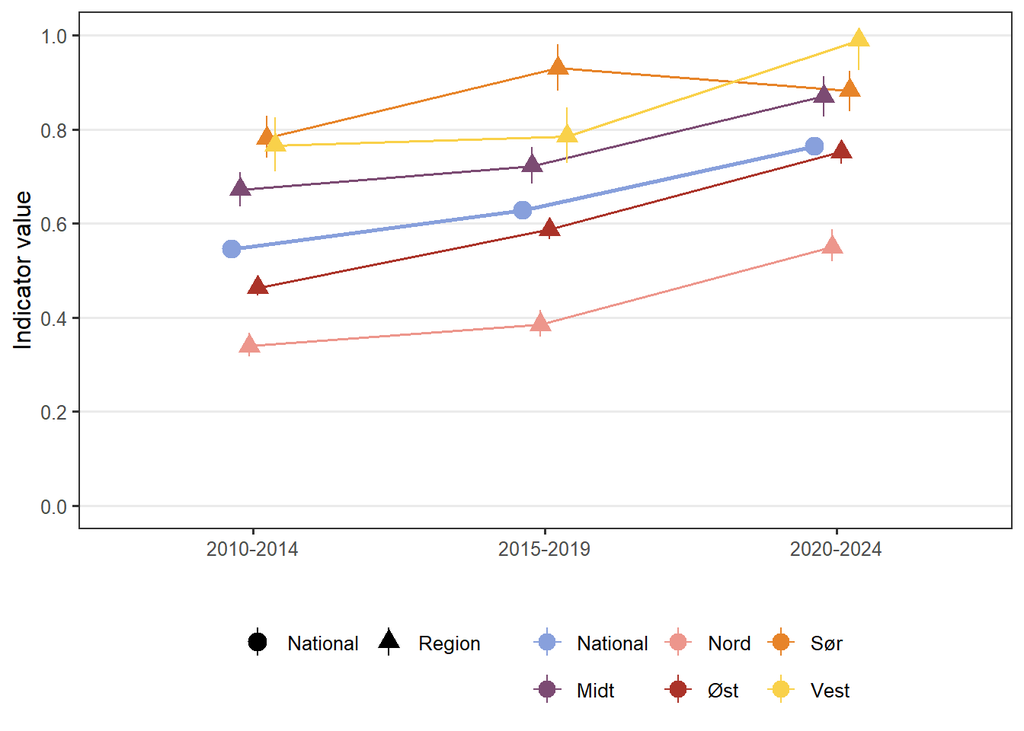

Figure 2: Indicator values for bilberry cover by area by region and reporting period. Points show the MC median; error bars are 95% credible intervals from the Monte Carlo propagation. National values use filled circles and a thicker line.

```r
blaa_region_labels <- c(
  "1" = "Øst", "2" = "Sør", "3" = "Vest",
  "4" = "Midt", "5" = "Nord", "National" = "National"
)
blaa_region_levels <- c("National", "Midt", "Nord", "Øst", "Sør", "Vest")
blaa_region_cols <- setNames(
  MetBrewer::met.brewer("Archambault", n = length(blaa_region_levels)),
  blaa_region_levels
)

blaa_plot_data <- blaa_mc_combined |>
  dplyr::mutate(
    region_name = dplyr::recode(region, !!!blaa_region_labels),
    series_type = dplyr::if_else(region == "National", "National", "Region")
  ) |>
  dplyr::group_by(period, region_name, series_type) |>
  dplyr::summarise(
    median = median(sampled_mean),
    p_025  = as.numeric(quantile(sampled_mean, 0.025)),
    p_975  = as.numeric(quantile(sampled_mean, 0.975)),
    .groups = "drop"
  ) |>
  dplyr::mutate(region_name = factor(region_name, levels = blaa_region_levels))

ggplot2::ggplot(blaa_plot_data,
                ggplot2::aes(x = period, y = median, colour = region_name, group = region_name)) +
  ggplot2::geom_line(
    ggplot2::aes(linewidth = series_type),
    position = ggplot2::position_dodge(width = 0.18)
  ) +
  ggplot2::geom_pointrange(
    ggplot2::aes(ymin = p_025, ymax = p_975, shape = series_type),
    size = 0.8, linewidth = 0.45,
    position = ggplot2::position_dodge(width = 0.18)
  ) +
  ggplot2::scale_colour_manual(values = blaa_region_cols, name = NULL) +
  ggplot2::scale_shape_manual(values = c(National = 19, Region = 17), name = NULL) +
  ggplot2::scale_linewidth_manual(values = c(National = 1, Region = 0.55), guide = "none") +
  ggplot2::scale_y_continuous(limits = c(0, 1), breaks = seq(0, 1, 0.2)) +
  ggplot2::theme_bw(base_size = 12) +
  ggplot2::theme(
    legend.position    = "bottom",
    legend.box         = "horizontal",
    panel.grid.minor   = ggplot2::element_blank(),
    panel.grid.major.x = ggplot2::element_blank()
  ) +
  ggplot2::guides(
    colour = ggplot2::guide_legend(nrow = 2,
                                   override.aes = list(size = 0.7, linewidth = 0.45)),
    shape  = ggplot2::guide_legend(override.aes = list(size = 0.8, linewidth = 0.45))
  ) +
  ggplot2::labs(y = "Indicator value", x = "")
```

### 10.1 County-level results (scaled with uncertainty)

Table 4: County or sub-county indicator values for bilberry cover by area by reporting period. Values are linearly scaled with county-specific *X<sub>0</sub>* and *X<sub>100</sub>* without truncation. The median is reported as the indicator value, with approximate 95% and interquartile intervals from the scaled draw distribution.

| ECT | Indicator | ID | Accounting area | Region | Sub-county | Ecosystem | Reporting period | Indicator value | 95% CI | 50% CI | Number of plots |
| --- | --- | --- | --- | --- | --- | --- | --- | --- | --- | --- | --- |
| B1 | Bilberry cover by area | NO_BLAA_001 | Oslo og Akershus | Øst | OA | Boreal/montane forests | 2010-2014 | 0.51 | 0.46 - 0.57 | 0.49 - 0.53 | 425 |
| B1 | Bilberry cover by area | NO_BLAA_001 | Vestfold | Øst | Ve | Boreal/montane forests | 2010-2014 | 0.4 | 0.3 - 0.49 | 0.36 - 0.43 | 171 |
| B1 | Bilberry cover by area | NO_BLAA_001 | Østfold | Øst | Øs | Boreal/montane forests | 2010-2014 | 0.38 | 0.33 - 0.44 | 0.36 - 0.4 | 325 |
| B1 | Bilberry cover by area | NO_BLAA_001 | Hordaland | Vest | Ho | Boreal/montane forests | 2010-2014 | 0.66 | 0.59 - 0.75 | 0.64 - 0.69 | 505 |
| B1 | Bilberry cover by area | NO_BLAA_001 | Rogaland | Vest | Ro | Boreal/montane forests | 2010-2014 | 0.87 | 0.75 - 1 | 0.83 - 0.92 | 258 |
| B1 | Bilberry cover by area | NO_BLAA_001 | Sogn og Fjordane | Vest | SF | Boreal/montane forests | 2010-2014 | 0.81 | 0.7 - 0.92 | 0.78 - 0.85 | 466 |
| B1 | Bilberry cover by area | NO_BLAA_001 | Møre og Romsdal | Midt | MR | Boreal/montane forests | 2010-2014 | 0.75 | 0.65 - 0.85 | 0.71 - 0.78 | 498 |
| B1 | Bilberry cover by area | NO_BLAA_001 | Finnmark | Nord | Fi | Boreal/montane forests | 2010-2014 | 0.14 | 0.11 - 0.17 | 0.13 - 0.15 | 176 |
| B1 | Bilberry cover by area | NO_BLAA_001 | Troms | Nord | Tr | Boreal/montane forests | 2010-2014 | 0.3 | 0.26 - 0.35 | 0.28 - 0.31 | 792 |
| B1 | Bilberry cover by area | NO_BLAA_001 | Aust-Agder | NA | AA | Boreal/montane forests | 2010-2014 | 0.85 | 0.76 - 0.94 | 0.82 - 0.88 | 551 |

[output cut: 59 more lines]

### 10.2 Regional results (scaled with uncertainty)

Table 5: Regional indicator values for bilberry cover by area by reporting period. Scaled values and uncertainty are derived from Monte Carlo propagation (1000 draws per region per period), with truncation to 0–1 applied after aggregation. The median is reported as the indicator value, with approximate 95% and interquartile intervals from the truncated MC distribution.

| ECT | Indicator | ID | Accounting area | Ecosystem | Reporting period | Indicator value | 95% CI | 50% CI | Number of plots |
| --- | --- | --- | --- | --- | --- | --- | --- | --- | --- |
| B1 | Bilberry cover by area | NO_BLAA_001 | Øst | Boreal/montane forests | 2010-2014 | 0.46 | 0.45 - 0.48 | 0.46 - 0.47 | 4,757 |
| B1 | Bilberry cover by area | NO_BLAA_001 | Sør | Boreal/montane forests | 2010-2014 | 0.78 | 0.74 - 0.83 | 0.76 - 0.8 | 1,898 |
| B1 | Bilberry cover by area | NO_BLAA_001 | Vest | Boreal/montane forests | 2010-2014 | 0.77 | 0.71 - 0.83 | 0.75 - 0.79 | 1,229 |
| B1 | Bilberry cover by area | NO_BLAA_001 | Midt | Boreal/montane forests | 2010-2014 | 0.67 | 0.64 - 0.71 | 0.66 - 0.68 | 2,377 |
| B1 | Bilberry cover by area | NO_BLAA_001 | Nord | Boreal/montane forests | 2010-2014 | 0.34 | 0.32 - 0.37 | 0.33 - 0.35 | 2,163 |
| B1 | Bilberry cover by area | NO_BLAA_001 | Øst | Boreal/montane forests | 2015-2019 | 0.59 | 0.57 - 0.61 | 0.58 - 0.59 | 4,741 |
| B1 | Bilberry cover by area | NO_BLAA_001 | Sør | Boreal/montane forests | 2015-2019 | 0.93 | 0.88 - 0.98 | 0.91 - 0.95 | 1,896 |
| B1 | Bilberry cover by area | NO_BLAA_001 | Vest | Boreal/montane forests | 2015-2019 | 0.79 | 0.73 - 0.85 | 0.77 - 0.8 | 1,192 |
| B1 | Bilberry cover by area | NO_BLAA_001 | Midt | Boreal/montane forests | 2015-2019 | 0.72 | 0.68 - 0.76 | 0.71 - 0.74 | 2,367 |
| B1 | Bilberry cover by area | NO_BLAA_001 | Nord | Boreal/montane forests | 2015-2019 | 0.39 | 0.36 - 0.42 | 0.37 - 0.39 | 2,202 |
| B1 | Bilberry cover by area | NO_BLAA_001 | Øst | Boreal/montane forests | 2020-2024 | 0.75 | 0.73 - 0.78 | 0.74 - 0.76 | 4,766 |
| B1 | Bilberry cover by area | NO_BLAA_001 | Sør | Boreal/montane forests | 2020-2024 | 0.88 | 0.84 - 0.93 | 0.87 - 0.9 | 1,896 |
| B1 | Bilberry cover by area | NO_BLAA_001 | Vest | Boreal/montane forests | 2020-2024 | 0.99 | 0.93 - 1 | 0.97 - 1 | 1,204 |
| B1 | Bilberry cover by area | NO_BLAA_001 | Midt | Boreal/montane forests | 2020-2024 | 0.87 | 0.83 - 0.91 | 0.85 - 0.89 | 2,363 |
| B1 | Bilberry cover by area | NO_BLAA_001 | Nord | Boreal/montane forests | 2020-2024 | 0.55 | 0.52 - 0.59 | 0.54 - 0.56 | 2,201 |

### 10.3 National results (scaled with uncertainty)

Table 6: National indicator values for bilberry cover by area by reporting period. Scaled values and uncertainty are derived from Monte Carlo propagation (1000 draws), with truncation to 0–1 applied after aggregation. The median is reported as the indicator value, with approximate 95% and interquartile intervals from the truncated MC distribution.

| ECT | Indicator | ID | Accounting area | Ecosystem | Reporting period | Indicator value | 95% CI | 50% CI | Number of plots |
| --- | --- | --- | --- | --- | --- | --- | --- | --- | --- |
| B1 | Bilberry cover by area | NO_BLAA_001 | National | Boreal/montane forests | 2010-2014 | 0.55 | 0.53 - 0.56 | 0.54 - 0.55 | 12,424 |
| B1 | Bilberry cover by area | NO_BLAA_001 | National | Boreal/montane forests | 2015-2019 | 0.63 | 0.61 - 0.64 | 0.62 - 0.63 | 12,398 |
| B1 | Bilberry cover by area | NO_BLAA_001 | National | Boreal/montane forests | 2020-2024 | 0.76 | 0.75 - 0.78 | 0.76 - 0.77 | 12,430 |

## 11. Export file

**Export regional and national MC-propagated indicator draws**

```r
write.csv(
  blaa_mc_combined,
  here::here("data/results_NO_BLAA_001.csv"),
  row.names = FALSE
)
```

## 12. Author contributions

**CRediT statement**

- Conceptualization: [EF, KOS, UJA]
- Methodology: [EF, KOS, UJA]
- Data curation: [OS]
- Formal analysis: [AHH]
- Validation: [AHH, KOS]
- Visualization: [AHH]
- Writing – original draft: [All]
- Writing – review & editing: [All]

**Session Info**

This workflow uses `renv`. Run `renv::restore()` to recreate the working environment.